# Customized fit

### Customized initialization

For this example, we won't run the optimizers for generating initial points. Instead, we'll create our own functions to create random initialization. For simplicity, we'll use uniform and gaussian functions. Although, any other kind of functions can be written to adapt to your needs.

```python
def unif(boundaries):
    """Generate uniform values between the minimum and maximum boundaries"""
    u = np.random.uniform(low=boundaries[0], high=boundaries[1])

    return u


def gauss(bounds, median, sigma):
    """Make a gaussian with restrictions"""
    while True:
        proposal = np.random.normal(loc=median, scale=sigma)

        # Verify that proposal is inside the physical bounds
        if bounds[0] <= proposal <= bounds[1]:
            return proposal
        else:
            pass
```

From the functions above, we passed the boundaries for individual parameters. In the case of the gaussian function, we also passed the median value and the standard deviation.

Let's see which are the planetary parameters and their boundaries from our Planetary System object

```python
pnames = PS.params_names.split()
my_boundaries = PS.bounds

list(zip(pnames, my_boundaries))
```

```
[('mass1', (1, 100)),
 ('period1', (22.95, 22.96)),
 ('ecc1', (1e-06, 0.2)),
 ('inclination1', (85, 95)),
 ('argument1', (0.0, 360)),
 ('mean_anomaly1', (0.0, 360)),
 ('mass2', (1, 100)),
 ('period2', (42.86, 42.87)),
 ('ecc2', (1e-06, 0.2)),
 ('argument2', (0.0, 360)),
 ('mean_anomaly2', (0.0, 360)),
 ('ascending_node2', (0.0, 180))]
```

In order to create our customized initialization, let's populate an array with entries in the SAME order as shown above. Note that for the gaussian initialization, median values inside the boundaries must be given. But first, Let's define the number of temperatures and walkers.

```python
nt = 12  # Number of temperatures
nw = 40  # Number of walkers
```

```python
my_init_walkers = np.zeros([nt, nw, PS.ndim])

# Create a customized initial walker population with the pre-defined functions
for t in range(nt):
    a = 2*(t+1)/nt  # a parameter to temperize the gaussian data
    for w in range(nw):

        my_init_walkers[t,w] = [
            gauss(PS.bounds[0], 50, 10*a),          # mass1
            gauss(PS.bounds[1], 22.955, 0.001*a),  # period1
            gauss(PS.bounds[2], 0.1, 0.02*a),     # ecc1
            unif(PS.bounds[3]),                    # inclination1
            unif(PS.bounds[4]),                    # argument1
            unif(PS.bounds[5]),                    # mean_anomaly1

            gauss(PS.bounds[6], 50, 10*a),          # mass2
            gauss(PS.bounds[7], 42.865, 0.001*a),  # period2
            gauss(PS.bounds[8], 0.1, 0.02*a),     # ecc2
            unif(PS.bounds[9]),                    # argument2
            unif(PS.bounds[10]),                   # mean_anomaly2
            unif(PS.bounds[11])                    # ascending_node2
            ]

my_init_walkers.shape
```

```
(12, 40, 12)
```

Note that we did a 'manual tempering' to mimic the strategies included in nauyaca. It's done to make broader gaussians for higher temperatures. However this step can be ommited setting constant widths (a=1).

Also note that in the array above, the constant parameters **are not included**. These are:

```python
for cp, val in PS.constant_params.items():
    print(f"{PS.params_names_all.split()[cp]} : {val}")
```

```
ascending_node1 : 89.0
inclination2 : 90.3
```

Let's inspect our customized initialization. For example, let's see the initial distribution of walkers for mass1, taking each 3 temperatures:

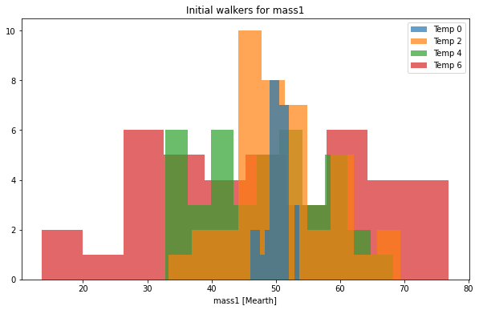

```python
plt.figure(figsize=(10,6))

for i, mp in enumerate(my_init_walkers[::3]):
    plt.hist(mp[:,0], alpha=0.7, label=f'Temp {i*2}',zorder=-i)

plt.legend()
plt.title('Initial walkers for mass1')
plt.xlabel('mass1 [Mearth]');
```

Let's compare the initialization in the eccentricity space for first and second planets:

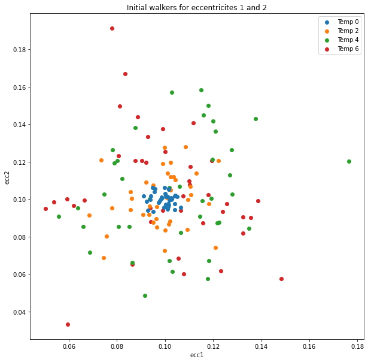

```python
plt.figure(figsize=(10,10))
for i, mp in enumerate(my_init_walkers[::3]):
    plt.scatter(mp[:,2], mp[:,8], label=f'Temp {i*2}', zorder=-i)

plt.legend()
plt.title('Initial walkers for eccentricites 1 and 2')
plt.xlabel('ecc1'); plt.ylabel('ecc2');
```

Now, we're almost ready to run the mcmc.